# 04_30 meet Richard

```r
#rmarkdown::render("reports/04_30_meet_Richard.Rmd") #to compile with the environment
knitr::opts_chunk$set(echo = TRUE)

#load required packages
library(rethinking)
library(rlist)

d <- list.load("../2_Data_preparation/processed_data.RData")
d$sex_col <- ifelse(d$S == "m", "darkblue", "darkred")#assign color to each sex
```

## Age and sex as predictors of knowledge

```r
#continuous  and sex
dat <- list( D = 1,
             N = as.integer(d$N - 1),
             L = d$L ,
             Q = d$Q ,    #n questionnaire items
             R = d$R ,    #n image recognition items
             S = as.integer(ifelse(d$S == "m", 1, 2) [-60]),
             A = standardize( d$A [d$A <= 50] ) ,  #round age [d$A <= 50]
             Y_l = d$Y_l [rownames(d$Y_l) != "19586",], # [rownames(d$Y_l) != "19586",]
             Y_q = d$Y_q [rownames(d$Y_l) != "19586",], #answers questionnaire
             Y_r = d$Y_r [rownames(d$Y_l) != "19586",]  #answers picture recognition
              )

m_lin <- stan( file =  "../models/1_dimensions_age_all_items.stan", data=dat , chains=3, cores=3) #K[i,j] = aK[i,j] + aS[S[i],j] + bA[S[i],j]*A[i];
```

This model has intercepts for individuals, intercepts and a slope for each sex - in correlation with age. The difference between sexes is not huge, but seems reliable and increases with age.

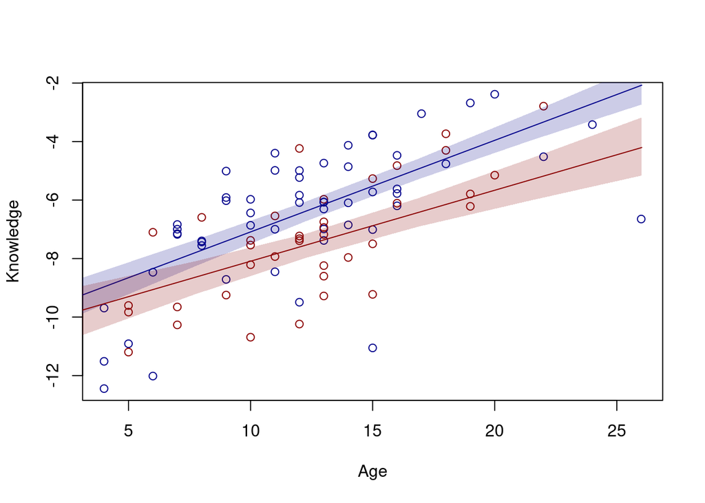

```r
post_l <- extract.samples(m_lin) #extract samples
plot_age_sex(post = post_l, d = d, dot_col = d$sex_col)
```

## ACTIVITIES

```r
#ACTIVITIES
dat <- list( D = 1,
             N = as.integer(d$N - 1),
             L = d$L ,
             Q = d$Q ,    #n questionnaire items
             R = d$R ,    #n image recognition items
             C = ncol(d$am),
             S = as.integer(ifelse(d$S == "m", 1, 2) [-60]),
             A = standardize( d$A [d$A <= 50] ) ,  #round age [d$A <= 50]
             AM = d$am [rownames(d$Y_l) != "19586",],
             Y_l = d$Y_l [rownames(d$Y_l) != "19586",], # [rownames(d$Y_l) != "19586",]
             Y_q = d$Y_q [rownames(d$Y_l) != "19586",], #answers questionnaire
             Y_r = d$Y_r [rownames(d$Y_l) != "19586",]  #answers picture recognition
)

m_act <- stan( file =  "../models/2_activities.stan", data=dat , chains=3, cores=3)
# K[i,j] = aK[i,j] + aS[S[i],j] + dot_product( aAM[,j], AM[i]) + bA[S[i],j]*A[i]
```

Now let’s have a look at the effect of activities.

Some activities have non-zero effect. Interestingly, the most negative effect is given by household chores and algae collection (respectively activity 1 and 9), two activities mostly performed by girls, and the most positive are from hunting with dogs and diving (respectively activity 4 and 8), typically performed by older boys.

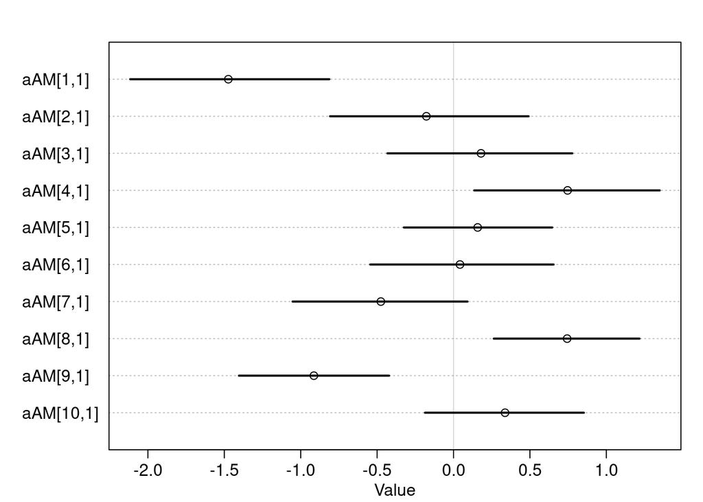

```r
plot (precis (m_act, 3, pars = "aAM"))
```

1 household_help 2 seashells 3 bird_hunting 4 hunt_with_dogs 5 field_help 6 cow_help 7 fishing 8 diving 9 mwani 10 karafu

Once activities are in the model, the effect of sex disappears.

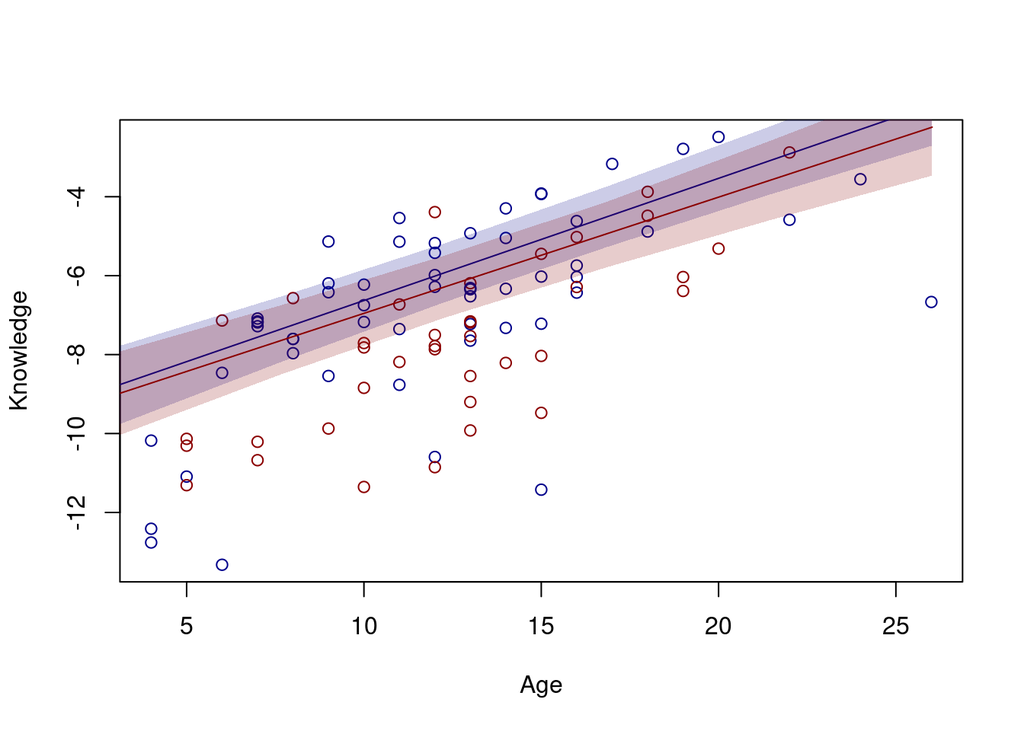

```r
post_a <- extract.samples(m_act) #extract samples
plot_age_sex(post = post_a, d = d, dot_col = d$sex_col)
```

## FAMILY

```r
#FAMILY
HHs <- data.frame("HH" =sort(unique(d$HH)), "n" = 1:36)
for (i in 1:nrow(HHs)) d$HHs [which(d$HH == HHs$HH[i])] <- HHs$n[i]
#intercept for household
dat <- list( D = 1,
             N = as.integer(d$N - 1),
             L = d$L ,
             Q = d$Q ,    #n questionnaire items
             R = d$R ,    #n image recognition items
             H = d$H ,    #n of households
             S = as.integer(ifelse(d$S == "m", 1, 2) [-60]),
             A = standardize( d$A [d$A <= 50] ) ,  #round age [d$A <= 50]
             HH = d$HHs [-60], #household of individuals
             Y_l = d$Y_l [rownames(d$Y_l) != "19586",], # [rownames(d$Y_l) != "19586",]
             Y_q = d$Y_q [rownames(d$Y_l) != "19586",], #answers questionnaire
             Y_r = d$Y_r [rownames(d$Y_l) != "19586",]  #answers picture recognition
)

m_fam <- stan( file =  "../models/2_family.stan", data=dat , chains=3, cores=3)
# K[i,j] = aK[i,j] + aS[S[i],j] + aH[HH[i],j]+ bA[S[i],j]*A[i];
```

Some families have a pretty significant negative impact.

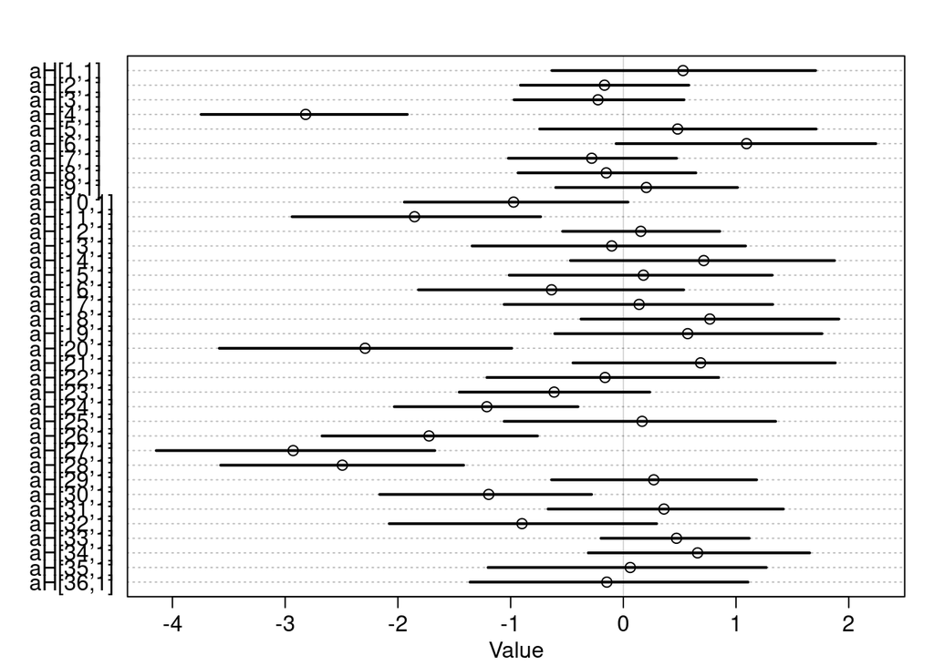

```r
plot(precis(m_fam, 3, pars = "aH"))
```

I don’t think this is due to the fact that they are represented by only one, maybe young, child, right? Lots of families have only one child…

```r
HHs <- data.frame("HH" =sort(unique(d$HH)), "n" = 1:36)
for (i in 1:nrow(HHs)) d$HHs [which(d$HH == HHs$HH[i])] <- HHs$n[i]
table(d$HHs)
```

```
##
##  1  2  3  4  5  6  7  8  9 10 11 12 13 14 15 16 17 18 19 20 21 22 23 24 25 26 27 28 29
##  1  6  6  5  1  1  6  5  4  3  2  7  1  1  1  1  1  1  1  1  1  2  4  5  1  3  1  2  3
## 30 31 32 33 34 35 36
##  3  2  1  7  2  1  1
```

## SCHOOL

```r
#SCHOOLING
#linear effect of school years
dat <- list( D = 1,
             N = as.integer(d$N - 1),
             L = d$L ,
             Q = d$Q ,    #n questionnaire items
             R = d$R ,    #n image recognition items
             S = as.integer(ifelse(d$S == "m", 1, 2) [-60]),
             A = standardize( d$A [d$A <= 50] ) ,  #round age [d$A <= 50]
             SY = standardize(d$SY) [-60] ,
             Y_l = d$Y_l [rownames(d$Y_l) != "19586",], # [rownames(d$Y_l) != "19586",]
             Y_q = d$Y_q [rownames(d$Y_l) != "19586",], #answers questionnaire
             Y_r = d$Y_r [rownames(d$Y_l) != "19586",]  #answers picture recognition
)

m_sch <- stan( file =  "../models/2_schooling.stan", data=dat , chains=3, cores=3)
# K[i,j] = aK[i,j] + aS[S[i],j] + bA[S[i],j]*A[i] + bSY[S[i],j]*SY[i];
```

there seem to be a slightly positive effect of spending time in school for the boys, not so much for the girls.

```r
precis(m_sch, 3, pars = "bSY")
```

```
##               mean        sd        5.5%     94.5%     n_eff    Rhat4
## bSY[1,1] 0.3594574 0.1942003  0.04675587 0.6616665  907.3973 1.002819
## bSY[2,1] 0.1206009 0.2541419 -0.28959428 0.5404151 2263.7795 1.000475
```

The effect seems minimal, though (is this the way to look at it?)

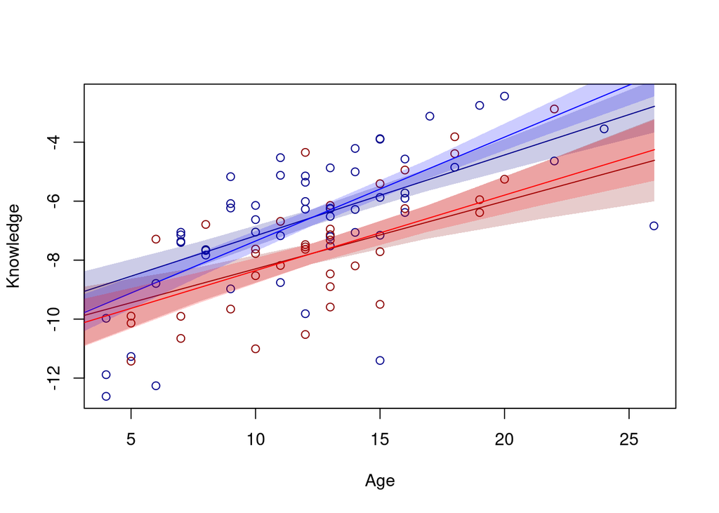

```r
post_s <- extract.samples(m_sch) #extract samples
dot_col <- d$sex_col
A_seq <- c( -2 : 3)#vector to loop over
  mus1 <- matrix(nrow = 3000, ncol = length(A_seq)) #create empty matrix to store the fit model over the sequence of data
  for (i in 1:length(A_seq)) {
    mus1[,i] <- apply(post_s$aK, 1, mean) + post_s$aS[,1,] + post_s$bA[,1,] * A_seq[i]                #calculate regression over the sequence of data A_seq, given the post_serior
  } #aK[i,j] + aS[S[i],j] + bA[S[i],j]*A[i]
  mus1.mean <- apply(mus1, 2, mean) #calculate average regression line
  mus1.PI <- apply(mus1, 2, PI) #calculate compatibility intervals
  mus2 <- matrix(nrow = 3000, ncol = length(A_seq)) #create empty matrix to store the fit model over the sequence of data
  for (i in 1:length(A_seq)) {
    mus2[,i] <- apply(post_s$aK, 1, mean) + post_s$aS[,2,] +  post_s$bA[,2,] * A_seq[i]  #need to get the SY from the correlated SY to each A
  } #aK[i,j] + aS[S[i],j] + bA[S[i],j]*A[i]
  mus2.mean <- apply(mus2, 2, mean)
  mus2.PI <- apply(mus2, 2, PI)

  mus1.1 <- matrix(nrow = 3000, ncol = length(A_seq)) #create empty matrix to store the fit model over the sequence of data
  for (i in 1:length(A_seq)) {
    mus1.1[,i] <- apply(post_s$aK, 1, mean) + post_s$aS[,1,] + post_s$bA[,1,] * A_seq[i] + post_s$bSY[,1,]*A_seq[i]                #calculate regression over the sequence of data A_seq, given the post_serior
  } #aK[i,j] + aS[S[i],j] + bA[S[i],j]*A[i] + bSY[S[i],j]*SY[i]
  mus1.1.mean <- apply(mus1.1, 2, mean) #calculate average regression line
  mus1.1.PI <- apply(mus1.1, 2, PI) #calculate compatibility intervals
  mus2.1 <- matrix(nrow = 3000, ncol = length(A_seq)) #create empty matrix to store the fit model over the sequence of data
  for (i in 1:length(A_seq)) {
    mus2.1[,i] <- apply(post_s$aK, 1, mean) + post_s$aS[,2,] +  post_s$bA[,2,] * A_seq[i] + post_s$bSY[,2,]*A_seq[i]   #need to get the SY from the correlated SY to each A
  } #aK[i,j] + aS[S[i],j] + bA[S[i],j]*A[i] + bSY[S[i],j]*SY[i]
  mus2.1.mean <- apply(mus2.1, 2, mean)
  mus2.1.PI <- apply(mus2.1, 2, PI)

    #plot
  plot( d$A[d$A <= 50], apply(post_s$K, 2, mean),
        xlab = "Age", ylab = "Knowledge", xaxt='n', col = dot_col )
  axis(1, c(5, 10, 15, 20, 25), at = )
  A_seq_real <- A_seq  * sd(d$A[d$A <= 50]) + mean(d$A[d$A <= 50])
  lines(A_seq_real, mus1.mean, col = "darkblue")
  shade(mus1.PI, A_seq_real, col = col.alpha("darkblue", 0.2))
  lines(A_seq_real, mus2.mean, col = "darkred")
  shade(mus2.PI, A_seq_real, col =  col.alpha("darkred", 0.2))
  lines(A_seq_real, mus1.1.mean, col = "blue")
  shade(mus1.1.PI, A_seq_real, col = col.alpha("blue", 0.2))
  lines(A_seq_real, mus2.1.mean, col = "red")
  shade(mus2.1.PI, A_seq_real, col =  col.alpha("red", 0.2))
```